# Lab Data Visualization with R Package ggplot2 part I

## Specifying Geometric Shapes - 3

What makes this really powerful is that you can add multiple geometries to a plot, thus allowing you to create complex graphics showing multiple aspects of your data.

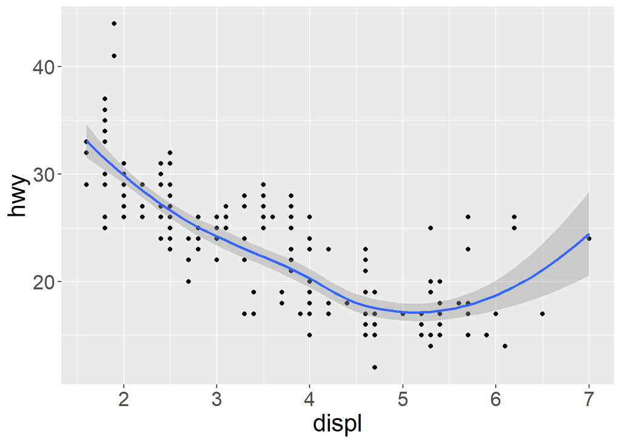

```r
# plot with both points and smoothed line
ggplot(mpg,
       aes(x = displ, y = hwy)) +
  geom_point() +
  geom_smooth()  +
  theme(text = element_text(size = 20))
```

## Specifying Geometric Shapes - 4

Since the aesthetics for each geom can be different, we could show multiple lines on the same plot (or with different colors, styles, etc).

For example, we can plot both points and a smoothed line for the same x and y variable but specify unique colors within each geom:

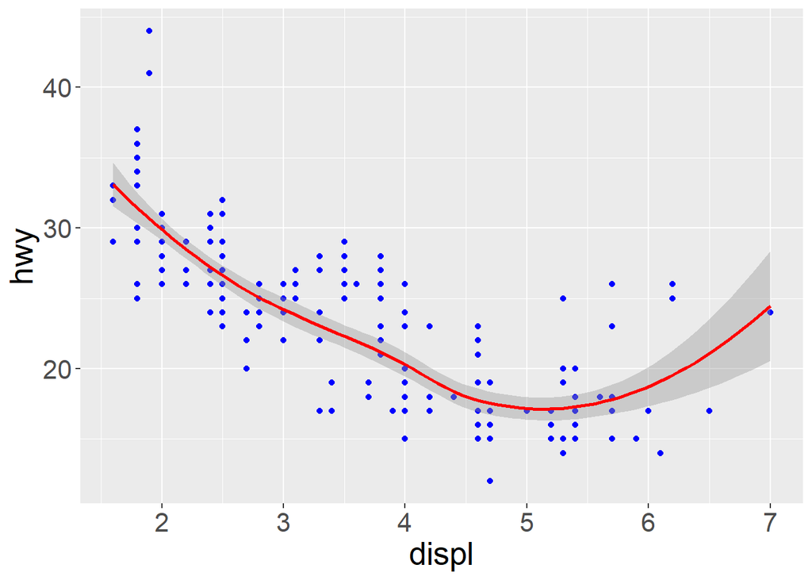

```r
ggplot(mpg,
       aes(x = displ, y = hwy)) +
  geom_point(color = "blue") +
  geom_smooth(color = "red")  +
  theme(text = element_text(size = 20))
```

## Specifying Geometric Shapes - 5

It is also possible to give each geom a different data argument, so that we can show multiple data sets in the same plot.

If we specify an aesthetic within ggplot(), it will be passed on to each geom that follows. Or we can specify certain aes within each geom, which allows us to only show certain characteristics for that specific layer (i.e. geom_point).

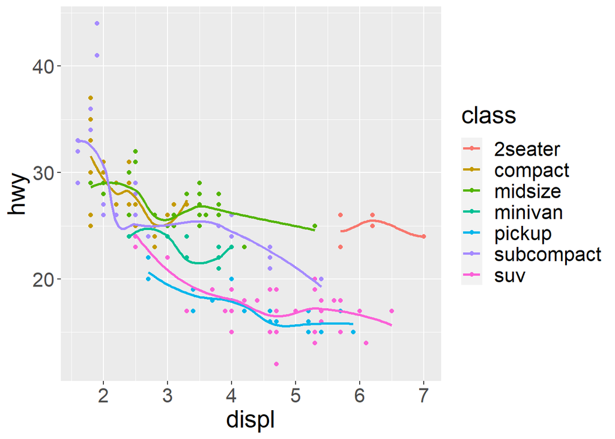

```r
# color aesthetic passed to each geom layer
ggplot(mpg,
       aes(x = displ, y = hwy, color = class)) +
  geom_point() +
  geom_smooth(se = FALSE) +
  theme(text = element_text(size = 20))
```

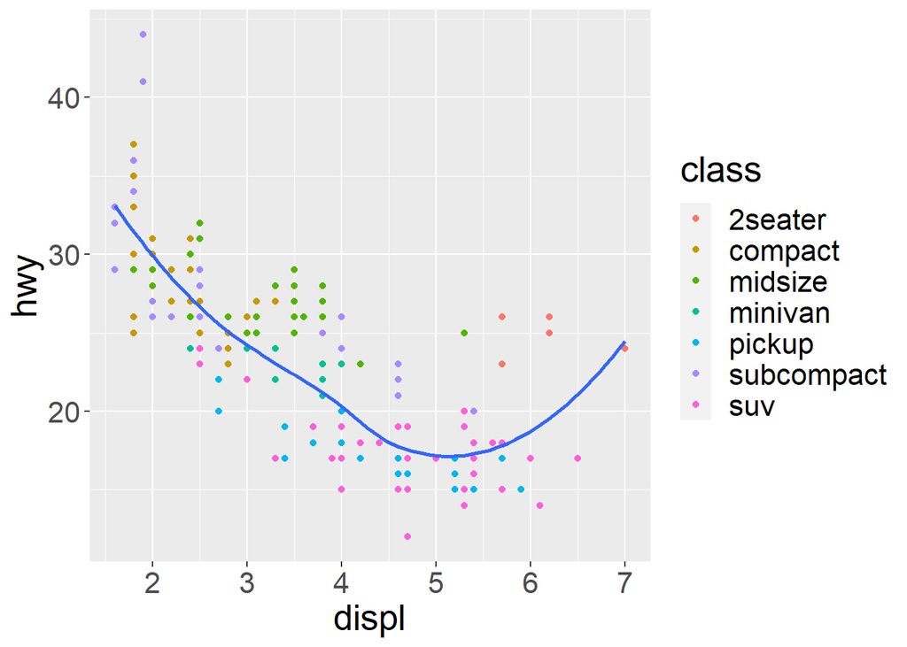

```r
# color aesthetic specified for only the geom_point layer
ggplot(mpg,
       aes(x = displ, y = hwy)) +
  geom_point(aes(color = class)) +
  geom_smooth(se = FALSE)  +
  theme(text = element_text(size = 20))
```

## Statistical Transformations - 1

The following bar chart shows the frequency distribution of vehicle class. We can find that y axis was defined as the count of elements that have the particular type. This count is not part of the data set, but is instead a statistical transformation that the geom_bar automatically applies to the data. In particular, it applies the stat_count transformation.

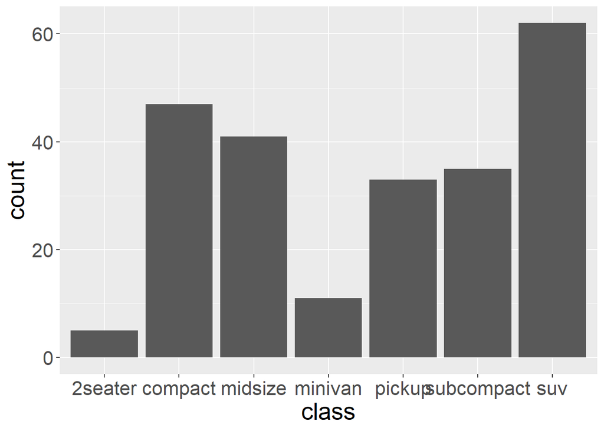

```r
ggplot(mpg,
       aes(x = class)) +
  geom_bar() +
  theme(text = element_text(size = 20))
```

## Statistical Transformations - 2

ggplot2 supports many different statistical transformations. For example, the “identity” transformation will leave the data “as is”. We can specify which statistical transformation a geom uses by passing it as the stat argument. For example, consider our data already had the count as a variable:

```r
(class_count <- count(mpg, class))
```

```
## # A tibble: 7 x 2
##   class          n
##   <chr>      <int>
## 1 2seater        5
## 2 compact       47
## 3 midsize       41
## 4 minivan       11
## 5 pickup        33
## 6 subcompact    35
## 7 suv           62
```

## Statistical Transformations - 3

We can use stat = “identity” within geom_bar to plot our bar height values to this variable. Also, note that we now include n for our y variable:

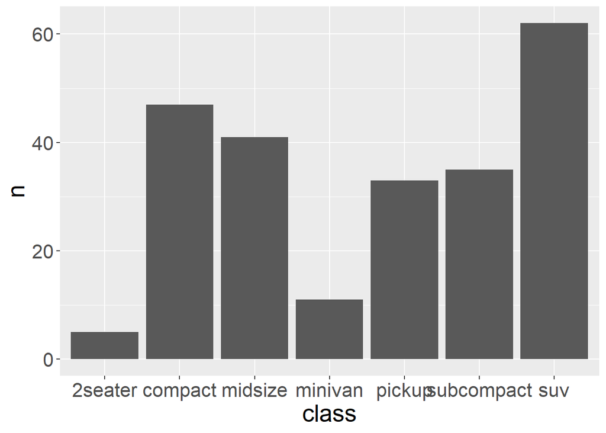

```r
ggplot(class_count,
       aes(x = class, y = n)) +
  geom_bar(stat = "identity") +
  theme(text = element_text(size = 20))
```

## Statistical Transformations - 4

We can also call stat_ functions directly to add additional layers. For example, here we create a scatter plot of highway miles for each displacement value and then use stat_summary() to plot the mean highway miles at each displacement value.

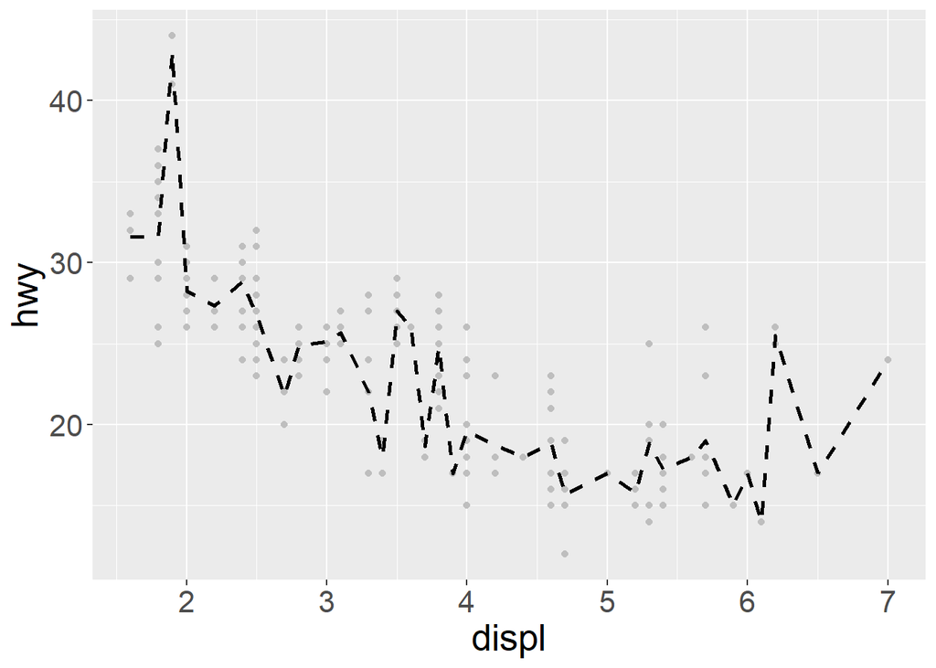

```r
ggplot(mpg,
       aes(displ, hwy)) +
  geom_point(color = "grey") +
  stat_summary(fun.y = "mean", geom = "line",
               size = 1, linetype = "dashed") +
  theme(text = element_text(size = 20))
```